# Celijah_ML4 - Customer Rating of Breakfast Cereals

Celijah

11/10/2019

## Load Data Set and Libraries

To begin, all packages required for this assignment is loaded.

The required dataset is imported into RStudio environment: “cereal.csv”

```r
# Import data set from BlackBoard into the RStudio environment

cereal <- read.csv("C:/Users/Stan/Documents/Cereals.csv")
```

## We need to review the structure of the dataset.

The summary below shows the structure of the dataset.

```r
# Review first few rows of the data set

head(cereal)
```

```
##                        name mfr type calories protein fat sodium fiber
## 1                 100%_Bran   N    C       70       4   1    130  10.0
## 2         100%_Natural_Bran   Q    C      120       3   5     15   2.0
## 3                  All-Bran   K    C       70       4   1    260   9.0
## 4 All-Bran_with_Extra_Fiber   K    C       50       4   0    140  14.0
## 5            Almond_Delight   R    C      110       2   2    200   1.0
## 6   Apple_Cinnamon_Cheerios   G    C      110       2   2    180   1.5
##   carbo sugars potass vitamins shelf weight cups   rating
## 1   5.0      6    280       25     3      1 0.33 68.40297
## 2   8.0      8    135        0     3      1 1.00 33.98368
## 3   7.0      5    320       25     3      1 0.33 59.42551
## 4   8.0      0    330       25     3      1 0.50 93.70491
## 5  14.0      8     NA       25     3      1 0.75 34.38484
## 6  10.5     10     70       25     1      1 0.75 29.50954
```

```r
# Investigate the structure of the data set

str(cereal)
```

```
## 'data.frame':    77 obs. of  16 variables:
##  $ name    : Factor w/ 77 levels "100%_Bran","100%_Natural_Bran",..: 1 2 3 4 5 6 7 8 9 10 ...
##  $ mfr     : Factor w/ 7 levels "A","G","K","N",..: 4 6 3 3 7 2 3 2 7 5 ...
##  $ type    : Factor w/ 2 levels "C","H": 1 1 1 1 1 1 1 1 1 1 ...
##  $ calories: int  70 120 70 50 110 110 110 130 90 90 ...
##  $ protein : int  4 3 4 4 2 2 2 3 2 3 ...
##  $ fat     : int  1 5 1 0 2 2 0 2 1 0 ...
##  $ sodium  : int  130 15 260 140 200 180 125 210 200 210 ...
##  $ fiber   : num  10 2 9 14 1 1.5 1 2 4 5 ...
##  $ carbo   : num  5 8 7 8 14 10.5 11 18 15 13 ...
##  $ sugars  : int  6 8 5 0 8 10 14 8 6 5 ...
##  $ potass  : int  280 135 320 330 NA 70 30 100 125 190 ...
##  $ vitamins: int  25 0 25 25 25 25 25 25 25 25 ...
##  $ shelf   : int  3 3 3 3 3 1 2 3 1 3 ...
##  $ weight  : num  1 1 1 1 1 1 1 1.33 1 1 ...
##  $ cups    : num  0.33 1 0.33 0.5 0.75 0.75 1 0.75 0.67 0.67 ...
##  $ rating  : num  68.4 34 59.4 93.7 34.4 ...
```

```r
# Investigate the summary of the data set

summary(cereal)
```

```
##                         name    mfr    type      calories
##  100%_Bran                : 1   A: 1   C:74   Min.   : 50.0
##  100%_Natural_Bran        : 1   G:22   H: 3   1st Qu.:100.0
##  All-Bran                 : 1   K:23          Median :110.0
##  All-Bran_with_Extra_Fiber: 1   N: 6          Mean   :106.9
##  Almond_Delight           : 1   P: 9          3rd Qu.:110.0
##  Apple_Cinnamon_Cheerios  : 1   Q: 8          Max.   :160.0
##  (Other)                  :71   R: 8
##     protein           fat            sodium          fiber
##  Min.   :1.000   Min.   :0.000   Min.   :  0.0   Min.   : 0.000
##  1st Qu.:2.000   1st Qu.:0.000   1st Qu.:130.0   1st Qu.: 1.000
##  Median :3.000   Median :1.000   Median :180.0   Median : 2.000
##  Mean   :2.545   Mean   :1.013   Mean   :159.7   Mean   : 2.152
##  3rd Qu.:3.000   3rd Qu.:2.000   3rd Qu.:210.0   3rd Qu.: 3.000
##  Max.   :6.000   Max.   :5.000   Max.   :320.0   Max.   :14.000
##
##      carbo          sugars           potass          vitamins
##  Min.   : 5.0   Min.   : 0.000   Min.   : 15.00   Min.   :  0.00
##  1st Qu.:12.0   1st Qu.: 3.000   1st Qu.: 42.50   1st Qu.: 25.00
##  Median :14.5   Median : 7.000   Median : 90.00   Median : 25.00
##  Mean   :14.8   Mean   : 7.026   Mean   : 98.67   Mean   : 28.25
##  3rd Qu.:17.0   3rd Qu.:11.000   3rd Qu.:120.00   3rd Qu.: 25.00
##  Max.   :23.0   Max.   :15.000   Max.   :330.00   Max.   :100.00
##  NA's   :1      NA's   :1        NA's   :2
##      shelf           weight          cups           rating
##  Min.   :1.000   Min.   :0.50   Min.   :0.250   Min.   :18.04
##  1st Qu.:1.000   1st Qu.:1.00   1st Qu.:0.670   1st Qu.:33.17
##  Median :2.000   Median :1.00   Median :0.750   Median :40.40
##  Mean   :2.208   Mean   :1.03   Mean   :0.821   Mean   :42.67
##  3rd Qu.:3.000   3rd Qu.:1.00   3rd Qu.:1.000   3rd Qu.:50.83
##  Max.   :3.000   Max.   :1.50   Max.   :1.500   Max.   :93.70
##
```

## Data Preprocessing

We will scale the data before removing the NA values from the dataset.

```r
# Create duplicate of data set for preprocessing

scaled_data <- cereal

# Scale the data set prior to placing it into a clustering algorithm

scaled_data[ , c(4:16)] <- scale(cereal[ , c(4:16)])

# Remove NA values from data set

cereal_preprocessed <- na.omit(scaled_data)

# Review the scaled data set with NA's removed

head(cereal_preprocessed)
```

```
##                        name mfr type   calories    protein         fat
## 1                 100%_Bran   N    C -1.8929836  1.3286071 -0.01290349
## 2         100%_Natural_Bran   Q    C  0.6732089  0.4151897  3.96137277
## 3                  All-Bran   K    C -1.8929836  1.3286071 -0.01290349
## 4 All-Bran_with_Extra_Fiber   K    C -2.9194605  1.3286071 -1.00647256
## 6   Apple_Cinnamon_Cheerios   G    C  0.1599704 -0.4982277  0.98066557
## 7               Apple_Jacks   K    C  0.1599704 -0.4982277 -1.00647256
##       sodium       fiber      carbo     sugars     potass   vitamins
## 1 -0.3539844  3.29284661 -2.5087829 -0.2343906  2.5753685 -0.1453172
## 2 -1.7257708 -0.06375361 -1.7409943  0.2223705  0.5160205 -1.2642598
## 3  1.1967306  2.87327158 -1.9969238 -0.4627711  3.1434645 -0.1453172
## 4 -0.2346986  4.97114672 -1.7409943 -1.6046739  3.2854885 -0.1453172
## 6  0.2424445 -0.27354112 -1.1011705  0.6791317 -0.4071355 -0.1453172
## 7 -0.4136273 -0.48332864 -0.9732057  1.5926539 -0.9752315 -0.1453172
##        shelf     weight       cups     rating
## 1  0.9515734 -0.1967771 -2.1100340  1.8321876
## 2  0.9515734 -0.1967771  0.7690100 -0.6180571
## 3  0.9515734 -0.1967771 -2.1100340  1.1930986
## 4  0.9515734 -0.1967771 -1.3795303  3.6333849
## 6 -1.4507595 -0.1967771 -0.3052601 -0.9365625
## 7 -0.2495930 -0.1967771  0.7690100 -0.6756899
```

Note that scaling the data reduced the initial number of observations from 77 to 74. This shows that there were three records with missing values.

## Problem A

“Apply hierarchical clustering to the data using Euclidean distance to the normalized measurements. Use Agnes to compare the clustering from single linkage, complete linkage, average linkage, and Ward. Choose the best method.”

Single Linkage:

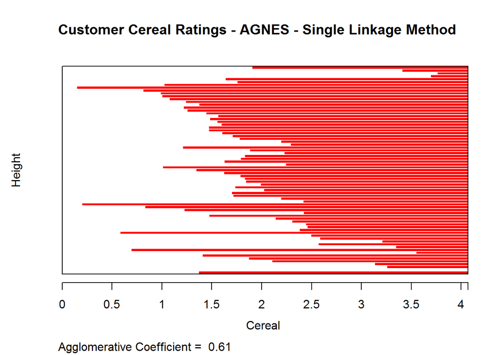

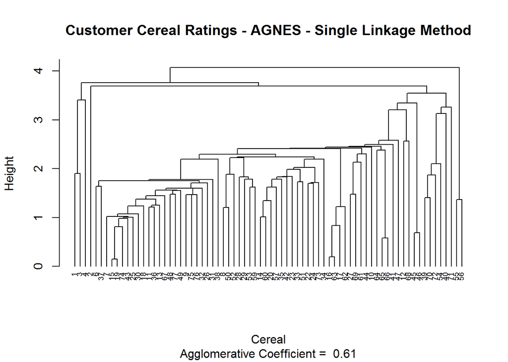

```r
# Dissimilarity matrix for the numeric values in the data set using Euclidean distance measurements

data_euclidean <- dist(cereal_preprocessed[ , c(4:16)], method = "euclidean")

# Perform hierarchical clustering via the single linkage method

ag_hc_single <- agnes(data_euclidean, method = "single")

# Plot the results of the different methods

plot(ag_hc_single,
     main = "Customer Cereal Ratings - AGNES - Single Linkage Method",
     xlab = "Cereal",
     ylab = "Height",
     cex.axis = 1,
     cex = 0.6,
     hang = -1)
```

Complete Linkage:

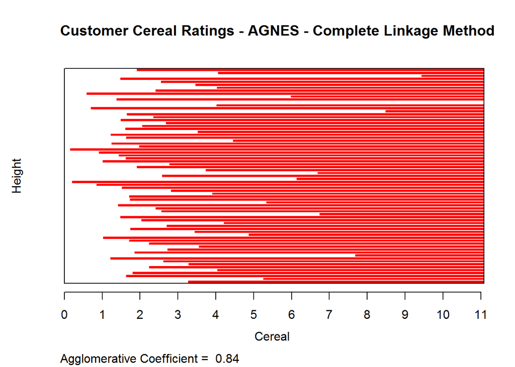

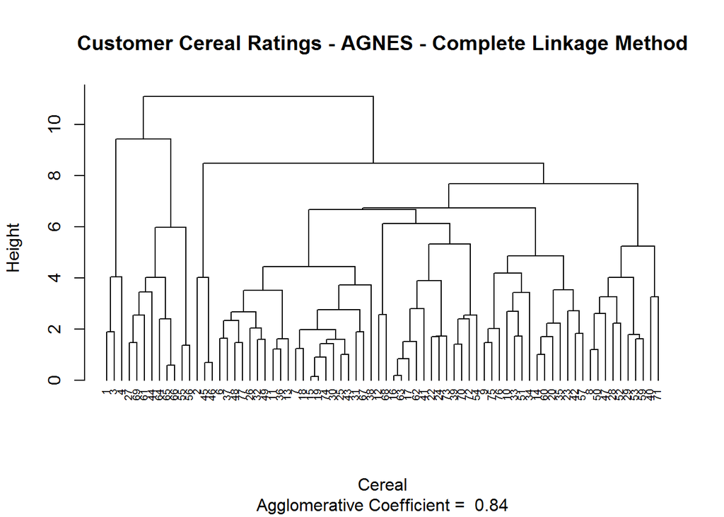

```r
# Perform hierarchical clustering using complete linkage method

ag_hc_complete <- agnes(data_euclidean, method = "complete")

# Plot the results of the different methods

plot(ag_hc_complete,
     main = "Customer Cereal Ratings - AGNES - Complete Linkage Method",
     xlab = "Cereal",
     ylab = "Height",
     cex.axis = 1,
     cex = 0.6,
     hang = -1)
```

Average Linkage:

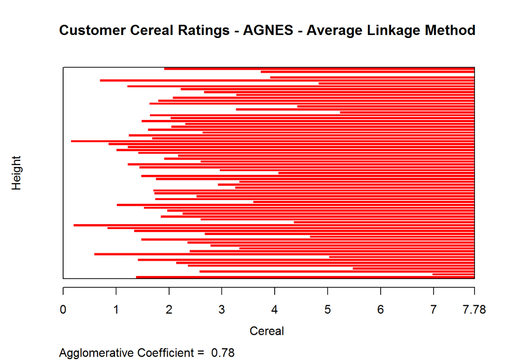

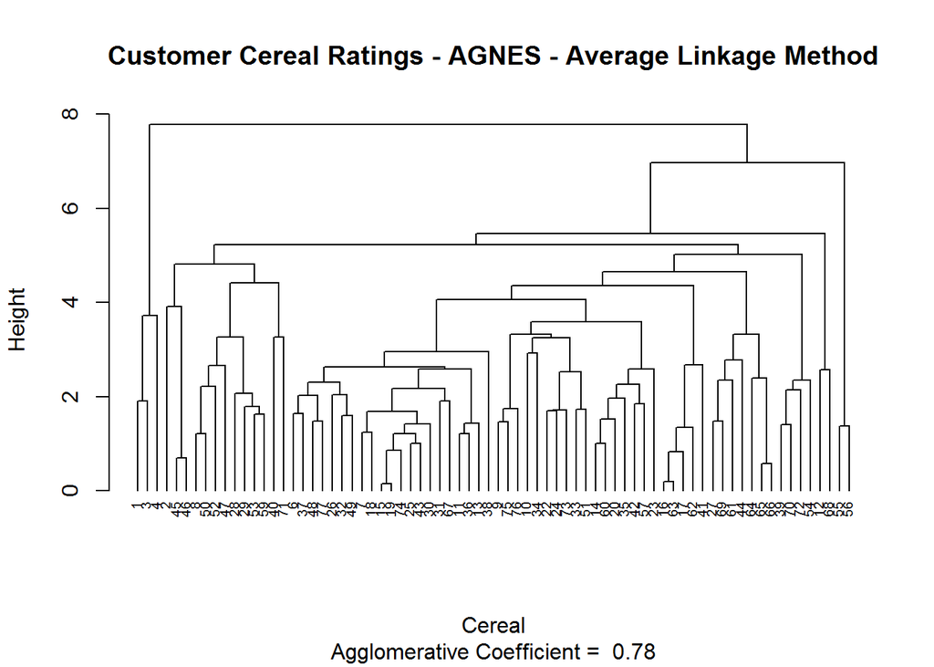

```r
# Perform hierarchical clustering using average linkage method

ag_hc_average <- agnes(data_euclidean, method = "average")

# Plot the results of the different methods

plot(ag_hc_average,
     main = "Customer Cereal Ratings - AGNES - Average Linkage Method",
     xlab = "Cereal",
     ylab = "Height",
     cex.axis = 1,
     cex = 0.6,
     hang = -1)
```

Ward Method:

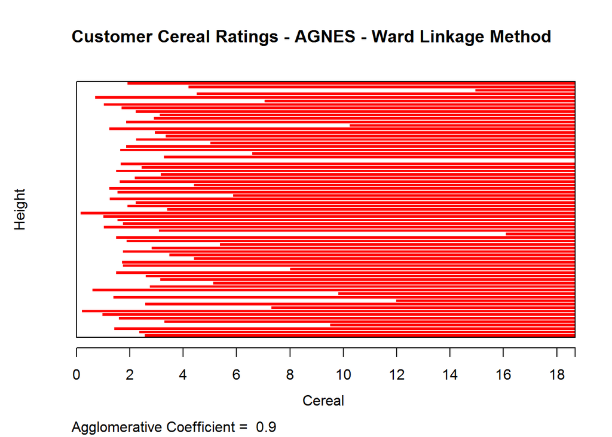

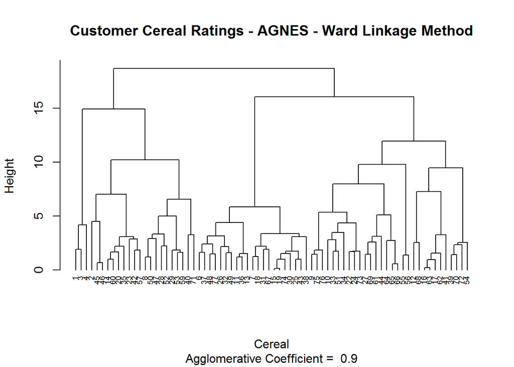

```r
# Perform hierarchical clustering using the ward linkage method

ag_hc_ward <- agnes(data_euclidean, method = "ward")

# Plot the results of the different methods

plot(ag_hc_ward,
     main = "Customer Cereal Ratings - AGNES - Ward Linkage Method",
     xlab = "Cereal",
     ylab = "Height",
     cex.axis = 1,
     cex = 0.6,
     hang = -1)
```

The agglomerative coefficient provides the values for determing the best clutering method. Any method that provides a value closest to 1.0 will be a fitting candidate for the best clustering method because the closest the agglomerative value to 1.0 the better and closer the clustering will be.

Single Linkage: 0.61 Complete Linkage: 0.84 Average Linkage: 0.78 Ward Method: 0.90

The output above shows that the Ward method will be chosen as the best clustering model in this problem because it emerged with the closest agglomerative value to 1. Therefore, best method chosen is Ward method = 0.90

## Problem B

“How many clusters would you choose?”

The Elbow and Silhouette methods to will be use to determine the appropriate number of clusters.

Elbow Method:

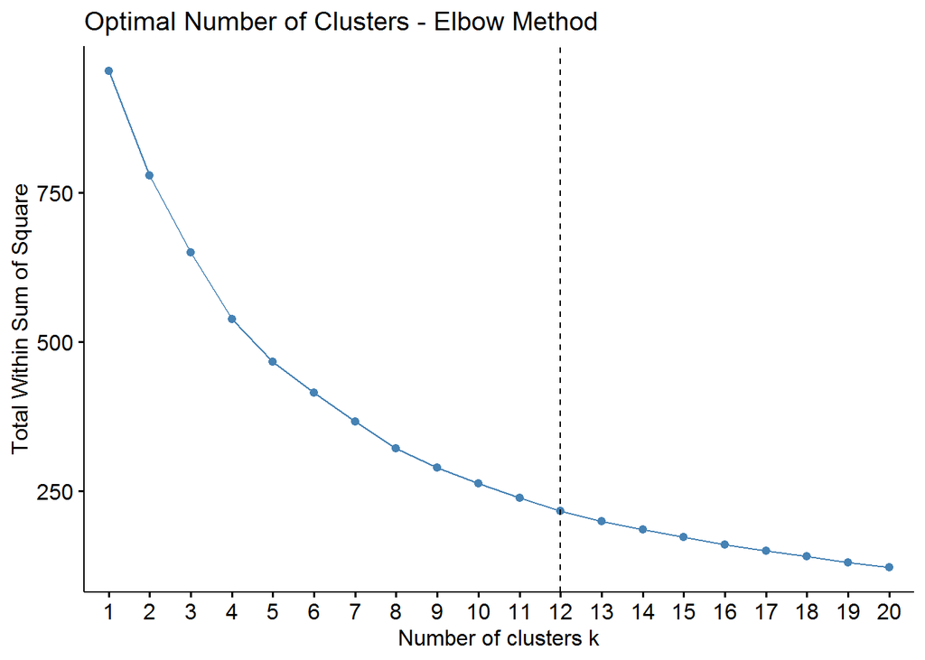

```r
# Determine the optimal number of clusters for the dataset via the Elbow method

fviz_nbclust(cereal_preprocessed[ , c(4:16)], hcut, method = "wss", k.max = 20) +
  labs(title = "Optimal Number of Clusters - Elbow Method") +
  geom_vline(xintercept = 12, linetype = 2)
```

Silhouette Method:

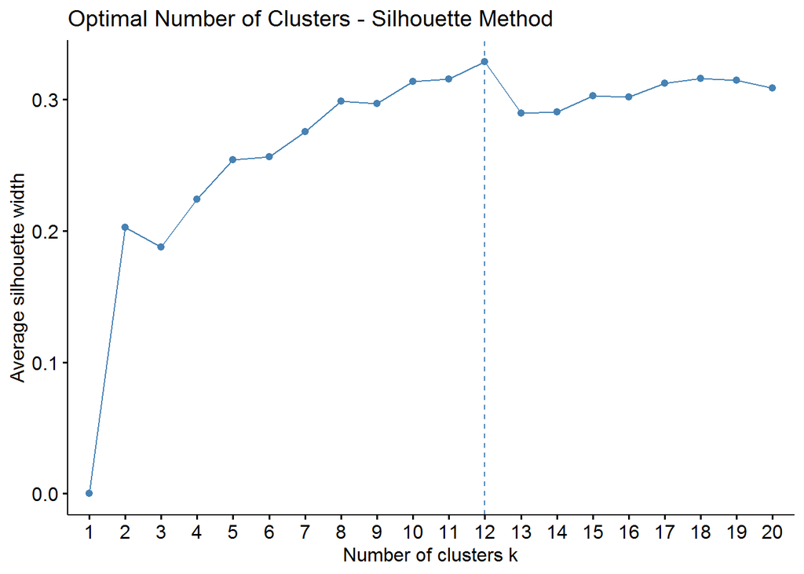

```r
# Determine the optimal number of clusters for the dataset via the silhouette method

fviz_nbclust(cereal_preprocessed[ , c(4:16)],
                               hcut,
                               method = "silhouette",
                               k.max = 20) +
  labs(title = "Optimal Number of Clusters - Silhouette Method")
```

#Next, we will outline the 12 clusters on the hierarchical tree using the Ward method since that was the best and chosen method.

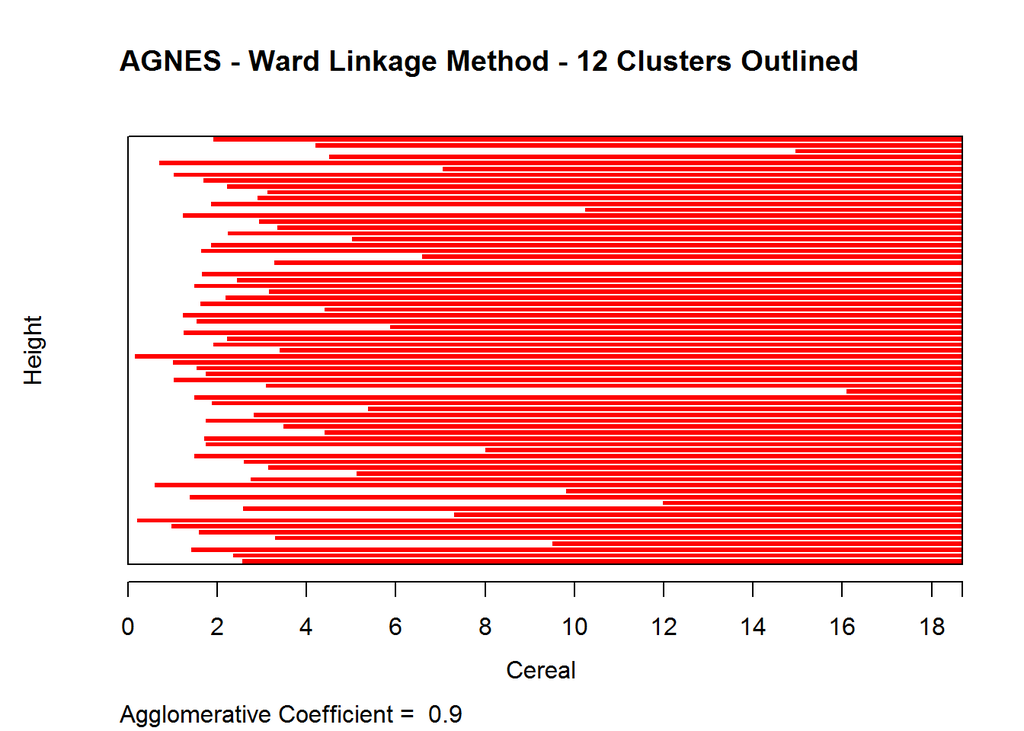

```r
# Plot of the Ward hierarchical tree with the 12 clusters outlined for reference

plot(ag_hc_ward,
     main = "AGNES - Ward Linkage Method - 12 Clusters Outlined",
     xlab = "Cereal",
     ylab = "Height",
     cex.axis = 1,
     cex = 0.6,
     hang = -1)
```

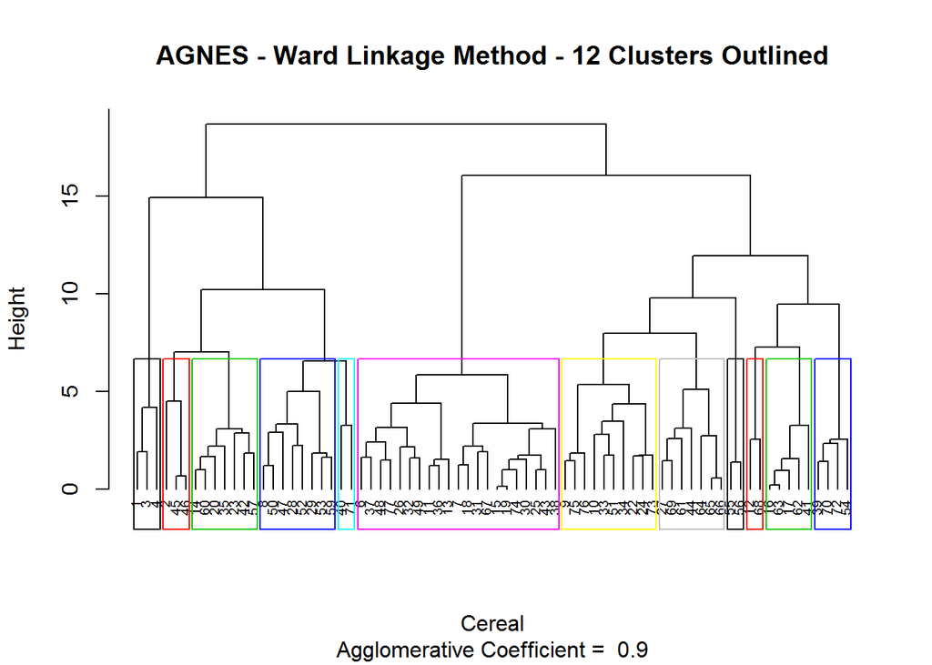

```r
rect.hclust(ag_hc_ward, k = 12, border = 1:12)
```

## Problem C

“Comment on the structure of the clusters and on their stability. Hint: To check stability, partition the data and see how well clusters formed based on one part apply to the other part. To do this: 1. Cluster partition A 2. Use the cluster centroids from A to assign each record in partition B (each record is assigned to the cluster with the closest centroid). 3. Assess how consistent the cluster assignments are compared to the assignments based on all the data”

All Data Assigned Clusters:

Note that in the “Data Preprocessing” session at the beginning of this document we defined All Data Assigned Clusters as “cereal_preprocessed”, there here we will call all data assigned clusters “cereal_preprocessed_1”

```r
# Now we will Cut the tree into 12 clusters for analysis

ward_clusters <- cutree(ag_hc_ward, k = 12)

# Add the assigned cluster to the preprocessed data set

cereal_preprocessed_1 <- cbind(cluster = ward_clusters, cereal_preprocessed)
```

Partition Data:

To check stability of clusters, the data set will be split into a 70% and 30% partition. We will use the 70% to create cluster assignments, and 30% will be assigned based on their closest centroid.

```r
# Set the seed for randomized functions

set.seed(111319)

# Split the data into 70% partition A and 30% partition B

cerealIndex <- createDataPartition(cereal_preprocessed$protein, p=0.3, list = F)

cereal_preprocessed_PartitionB <- cereal_preprocessed[cerealIndex, ]

cereal_preprocessed_PartitionA <- cereal_preprocessed[-cerealIndex,]
```

Next we will Re-Run Clustering with Partitioned Data:

To determine the stability of the clusters, we will use the same K value = 12 and ward clustering method.Then clusters will be assigned to the nearest points in Partition B (for clusters 1 to 12).

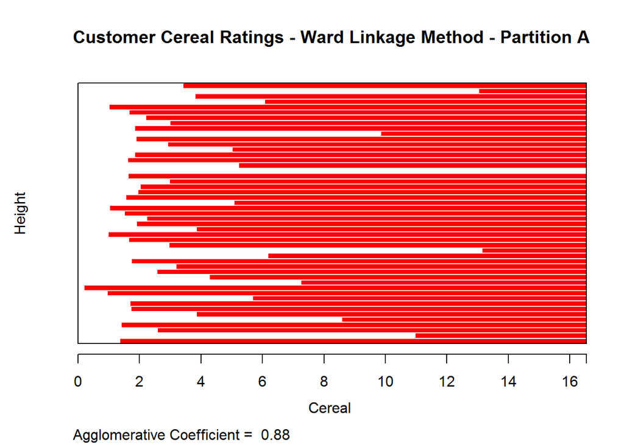

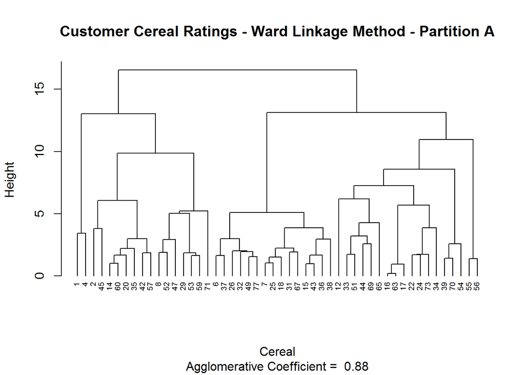

```r
# Dissimilarity matrix for the numeric values in the partitioned data set using Euclidean distance measurements

data_euclidean_A <- dist(cereal_preprocessed_PartitionA[ , c(4:16)], method = "euclidean")

# Perform hierarchical clustering via the ward linkage method on partitioned data

ag_hc_ward_A <- agnes(data_euclidean_A, method = "ward")

# Plot the results of the different methods

plot(ag_hc_ward_A,
     main = "Customer Cereal Ratings - Ward Linkage Method - Partition A",
     xlab = "Cereal",
     ylab = "Height",
     cex.axis = 1,
     cex = 0.6,
     hang = -1)
```

```r
# Cut the tree into 12 clusters for analysis

ward_clusters_A <- cutree(ag_hc_ward_A, k = 12)

# Add the assigned cluster to the preprocessed data set

cereal_preprocessed_A <- cbind(cluster = ward_clusters_A, cereal_preprocessed_PartitionA)
```

In other to find the closest centroid for the data points in partition B, we need to calculate the centroids for each of the clusters.

```r
# Next, we are Finding the centroids for the re-ran Ward hierarchical clustering

ward_Centroids_A <- aggregate(cereal_preprocessed_A[ , 5:17], list(cereal_preprocessed_A$cluster), mean)

ward_Centroids_A <- data.frame(Cluster = ward_Centroids_A[ , 1], Centroid = rowMeans(ward_Centroids_A[ , -c(1:4)]))

ward_Centroids_A <- ward_Centroids_A$Centroid
```

```r
# Now we calculate Centers of Partition B dataset

cereal_preprocessed_PartitionB_centers <- data.frame(cereal_preprocessed_PartitionB[, 1:3], Center = rowMeans(cereal_preprocessed_PartitionB[ , 4:16]))
```

```r
# And the distance between the centers of partition A and the values of partition B is calculated

B_to_A_centers <- dist(ward_Centroids_A, cereal_preprocessed_PartitionB_centers$Center, method = "euclidean")

# Clusters are assigned based on the shortest distance to cluster centers

cereal_preprocessed_B <- cbind(cluster = c(4,8,7,3,5,6,7,11,11,10,8,5,10,1,10,1,4,12,12,7,7,1,4,9), cereal_preprocessed_PartitionB)

# Combine partitions A and B for comparison to original clusters

cereal_preprocessed_2 <- rbind(cereal_preprocessed_A, cereal_preprocessed_B)

cereal_preprocessed_1 <- cereal_preprocessed_1[order(cereal_preprocessed_1$name), ]
cereal_preprocessed_2 <- cereal_preprocessed_2[order(cereal_preprocessed_2$name), ]
```

We are now ready to compare the number of matching assignments in other to determine the stability of the clusters.

```r
sum(cereal_preprocessed_1$cluster == cereal_preprocessed_2$cluster)
```

```
## [1] 33
```

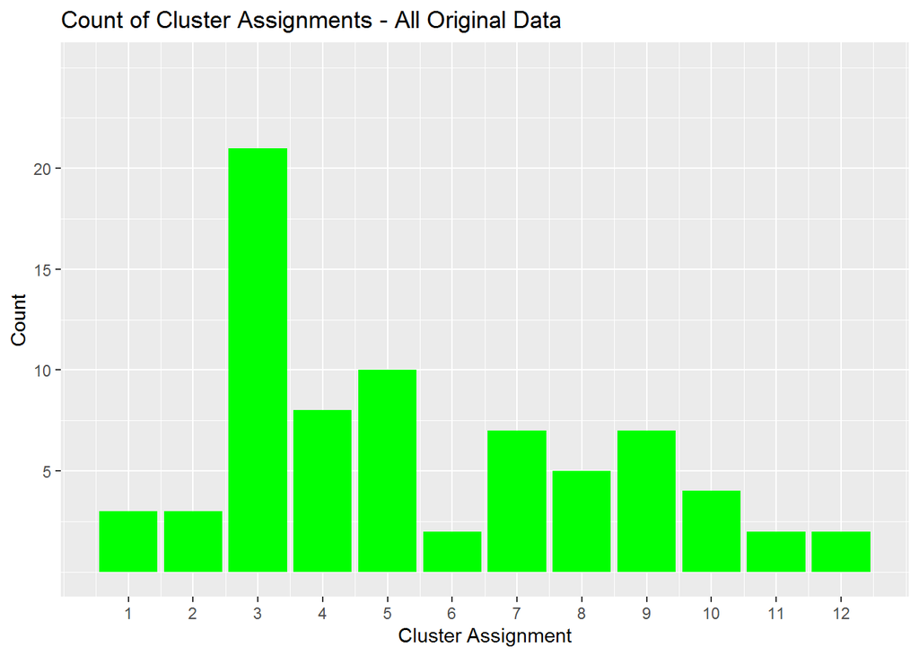

```r
# Visualization of cluster assignments to identify difference between the original data and the partitioned data.

# Plot of original hierarchical clustering algorithm

ggplot(data = cereal_preprocessed_1, aes(cereal_preprocessed_1$cluster)) +
  geom_bar(fill = "green") +
  labs(title="Count of Cluster Assignments - All Original Data") +
  labs(x="Cluster Assignment", y="Count") +
  guides(fill=FALSE) +
  scale_x_continuous(breaks=c(1:12)) +
  scale_y_continuous(breaks=c(5,10,15,20), limits = c(0,25))
```

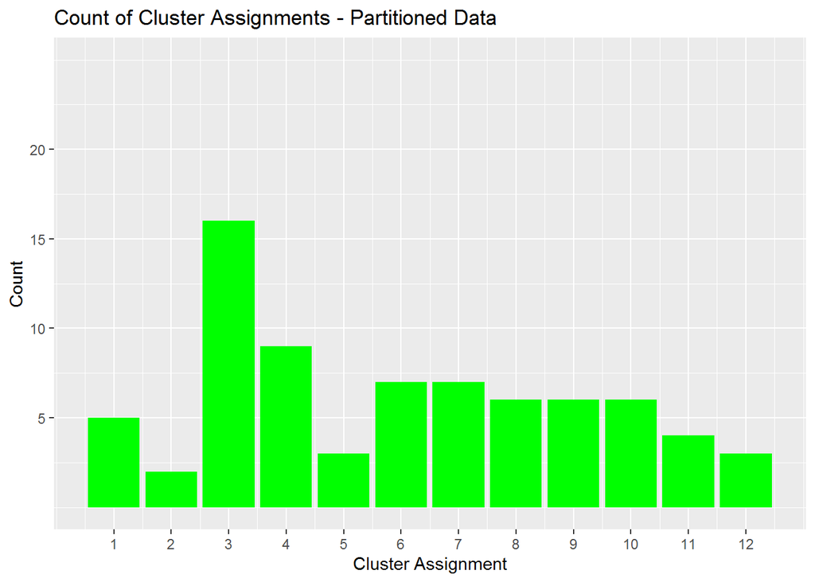

```r
# Plot of algorithm that was partitioned prior to assigning the remaining data

ggplot(data = cereal_preprocessed_2, aes(cereal_preprocessed_2$cluster)) +
  geom_bar(fill = "green") +
  labs(title="Count of Cluster Assignments - Partitioned Data") +
  labs(x="Cluster Assignment", y="Count") +
  guides(fill=FALSE) +
  scale_x_continuous(breaks=c(1:12)) +
  scale_y_continuous(breaks=c(5,10,15,20), limits = c(0,25))
```

## Problem D

“The elementary public schools would like to choose a set of cereals to include in their daily cafeterias. Every day a different cereal is offered, but all cereals should support a healthy diet. For this goal, you are requested to find a cluster of healthy cereals. Should the data be normalized? If not, how should they be used in the cluster analysis?”

NO, the data should not be normalized because when the data is normalise there are negative values. Realistically, there is no negative protein or any of the nutrients in the real World. Since we do not have enough information to determine a combinetion that is considered healthy cereals, the data can be clustered based on daily recommended calories.

Therefore, to analyze this data, the consultant should depend on the percentage of daily recommended intake of food calories for the clustering.